# Chapter 2: Overview of Supervised Learning

2021-05-09

# 2.2 Overview of Supervised Learning

It has been a few years since I took Linear Algebra, so I’ll use this section as a matrix notation refresher.

Consider an input vector $X$ with components indexed as $X_j$ ($j = 1, \dots, p$), and a quantitative output vector $Y$. We use $G$ for qualitative outputs, but will focus on quantitative for this example.

Observations of the generic $X$ and $Y$ are written in lowercase. The $i$th observation of $X$ is denoted $x_i$ ($i = 1, \dots, N$), which is a $p$-vector itself. A matrix of $N$ observations is represented by $\bf{X}$, with $N$ rows and $p$ columns:

$$\bf{X} =
\begin{bmatrix}
\bf{x}_1 \\
\bf{x}_2 \\
\vdots \\
\bf{x}_N
\end{bmatrix} =
\begin{bmatrix}
x_{11} & \cdots & x_{1p} \\
x_{21} & \cdots & x_{2p} \\
\vdots \\
x_{N1} & \cdots & x_{Np}
\end{bmatrix}$$

Note how the subscripts distinguish the input vectors:

- A single observation $x_i$ has $p$ elements for each input variable
  - e.g. for two inputs age and sex, an observation might be $x_i$ = (29 years, male)
- A vector $\bf{x}_j$ (note the bolding) consists of all $N$ observations for the variable $X_j$
  - e.g. for $N = 3$ observations of sex, $x_j$ = (male, female, female)

The age and sex example would have the following matrix of observations:

$$\bf{X} =
\begin{bmatrix}
29 & \text{male} \\
22 & \text{female} \\
30 & \text{female} \\
\end{bmatrix}$$

Since all vectors are assumed to be column vectors, the $i$th row of $\bf{X}$ is the vector transpose $x_i^T$:

$$x_i =
\begin{bmatrix}
29 \\ \text{male}
\end{bmatrix}
\rightarrow
x_i^T =
\begin{bmatrix}
29 & \text{male}
\end{bmatrix}$$

Matrices can be operated on in R with `matrix()`:

```r
a <-
  matrix(
    c(1, 2, 3,
      4, 5, 6),
    nrow = 2
  )
a
```

```
##      [,1] [,2] [,3]
## [1,]    1    3    5
## [2,]    2    4    6
```

We can get the transpose of a matrix with `t()`:

```r
t(a)
```

```
##      [,1] [,2]
## [1,]    1    2
## [2,]    3    4
## [3,]    5    6
```

Matrix multiplication can be done with the `%*%` operator (if they are conformable):

```r
b <-
  matrix(
    c(1, 2,
      3, 4,
      5, 6),
    nrow = 3
  )
c <- a %*% b
c
```

```
##      [,1] [,2]
## [1,]   22   49
## [2,]   28   64
```

A matrix $A \in \mathbb{R}^{2 \times 3}$ multiplied by $B \in \mathbb{R}^{3 \times 2}$ results in a matrix $C \in \mathbb{R}^{2 \times 2}$. If we were to, say, take the transpose of $A$, then $A^T \in \mathbb{R}^{3 \times 2}$ no longer conforms:

```r
t(a) %*% b
```

```
## Error in t(a) %*% b: non-conformable arguments
```

This has just scratched the surface of matrix algebra, but will do for now. Back to the point of of section 2.2:

> For the moment we can loosely state the learning task as follows: given the value of an input vector $X$, make a good prediction of the output $Y$, denoted by $\hat{Y}$. If $Y$ takes values in $\mathbb{R}$ then so should $\hat{Y}$; likewise for categorical outputs, $\hat{G}$ should take values in the same set $\mathcal{G}$ associated with $G$. (Hastie et al., 2009, p. 11)

# 2.3 Two Simple Approaches to Prediction: Least Squares and Nearest Neighbors

## 2.3.1 Linear Models and Least Squares

$$\hat{Y} = \hat{\beta}_0 + \sum_{j=1}^p X_j \hat{\beta}_j \tag{2.1}$$

The term $\hat{\beta}_0$ is the intercept, sometimes called the *bias* in machine learning. We can add $\hat{\beta}_0$ to the coefficients $\hat{beta}$ and write the above in vector notation:

$$\hat{Y} = X^T \hat{\beta} \tag{2.2}$$

When it comes to fitting the linear model, by far the most popular method is *least squares*, where the coefficients $\beta$ minimize the *residual sum of squares*:

$$\text{RSS}(\beta) \ \sum_{i=1}^N (y_i - x_i^T \beta)^2 \tag{2.3}$$

which is written in matrix notation as:

$$\text{RSS}(\beta) = (\bf{y} - \bf{X}\beta)^T(\bf{y} - \bf{X}\beta) \tag{2.4}$$

Differentiating with respect to $\beta$, and setting equal to 0 gives us the unique solution:

$$\hat{\beta} = (\bf{X}^T \bf{X})^{-1} \bf{X}^T \bf{y}$$

The data in Figure 2.1 are provided [online](https://web.stanford.edu/~hastie/ElemStatLearn/). Load the data:

```r
load(here("data", "ESL.mixture.rda"))
esl_mixture <- ESL.mixture
rm(ESL.mixture)
```

This gives us a list with 8 elements, all of which are numeric vectors/matrices. Reading the [data description file](https://web.stanford.edu/~hastie/ElemStatLearn/datasets/mixture.example.info.txt), looks like the data we want to plot are `x` and `y`:

```r
d_mixture <-
  tibble(
    x1 = esl_mixture$x[,1],
    x2 = esl_mixture$x[,2],
    y = esl_mixture$y
  )
d_mixture
```

| x1 | x2 | y |
| --- | --- | --- |
| 2.526092968 | 0.321050446 | 0 |
| 0.366954472 | 0.031462099 | 0 |
| 0.768219076 | 0.717486166 | 0 |
| 0.693435680 | 0.777194034 | 0 |
| -0.019836616 | 0.867253738 | 0 |
| 2.196544935 | -1.023014058 | 0 |
| -0.109159157 | -0.530621080 | 0 |
| -0.912620059 | 1.216216381 | 0 |
| 2.499842651 | -0.418277898 | 0 |
| 1.897709107 | 0.973755498 | 0 |

[output cut: 190 more lines]

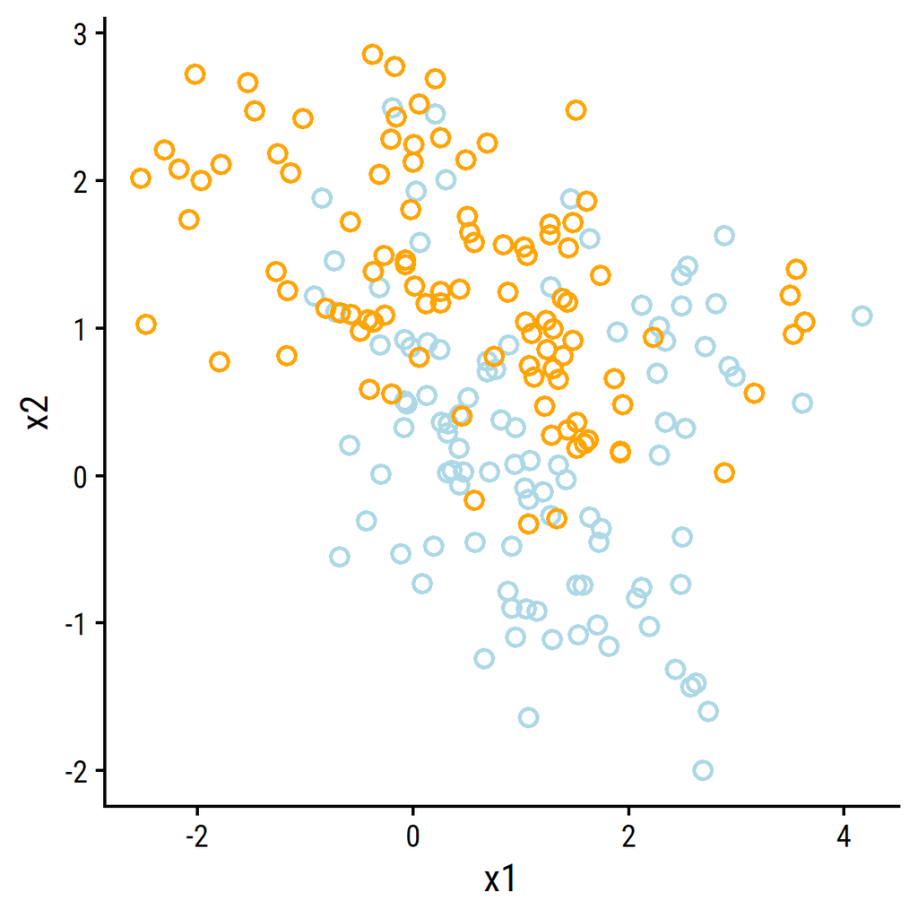

```r
p_fig2.1 <- d_mixture %>%
  ggplot(aes(x = x1, y = x2)) +
  geom_point(aes(color = factor(y)), shape = 21, size = 2, stroke = 1) +
  scale_color_manual(values = c("lightblue", "orange")) +
  theme(legend.position = "none")
p_fig2.1
```

Now our first chance to use `tidymodels`. Specify the linear regression model:

```r
library(tidymodels)
lm_spec <- linear_reg() %>%
  set_engine("lm") %>%
  set_mode("regression")
lm_spec
```

```
## Linear Regression Model Specification (regression)
##
## Computational engine: lm
```

Fit it to the data (no splitting into training and testing yet):

```r
lm_fit_mixture <- lm_spec %>%
  fit(y ~ x1 + x2, data = d_mixture)
lm_fit_mixture
```

```
## parsnip model object
##
## Fit time:  0ms
##
## Call:
## stats::lm(formula = y ~ x1 + x2, data = data)
##
## Coefficients:
## (Intercept)           x1           x2
##     0.32906     -0.02264      0.24960
```

The “testing” set is the grid of values `esl_mixture$xnew`:

```r
d_mixture_grid <- as_tibble(esl_mixture$xnew)
d_mixture_grid
```

| x1 | x2 |
| --- | --- |
| -2.6 | -2.00 |
| -2.5 | -2.00 |
| -2.4 | -2.00 |
| -2.3 | -2.00 |
| -2.2 | -2.00 |
| -2.1 | -2.00 |
| -2.0 | -2.00 |
| -1.9 | -2.00 |
| -1.8 | -2.00 |
| -1.7 | -2.00 |

[output cut: 6821 more lines]

which we then apply the fit model to and assign the observation $x_i$ to BLUE if $\hat{y}_i \leq 0.5$ , or ORANGE if $\hat{y}_i > 0.5$:

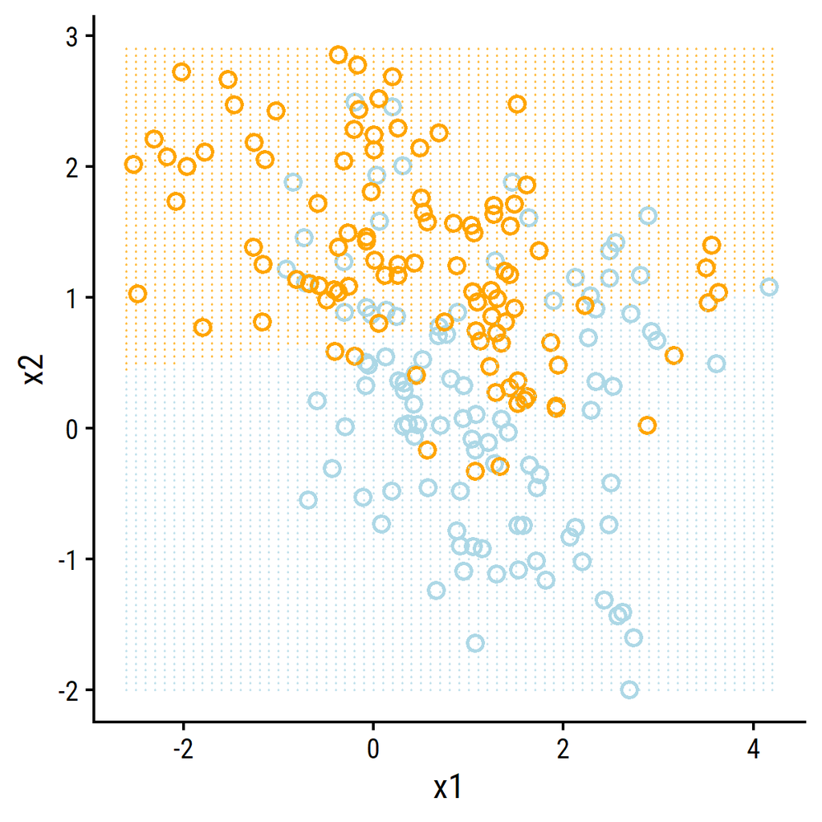

```r
d_mixture_grid_pred <-
  bind_cols(
    d_mixture_grid,
    predict(lm_fit_mixture, d_mixture_grid)
  ) %>%
  mutate(y = ifelse(.pred > 0.5, 1, 0))
p_fig2.1 <- p_fig2.1 +
  geom_point(
    data = d_mixture_grid_pred,
    aes(color = factor(y)), size = 0.05, alpha = 0.5
  )
p_fig2.1
```

And the last piece is to determine where to draw the decision boundary:

$$\begin{align}
y &= \beta_0 + x_1 \beta_1 + x_2 \beta_2 = 0.5 \\
\rightarrow x_2 &= \frac{0.5 - \beta_0 - x_1 \beta_1}{\beta_2}
\end{align}$$

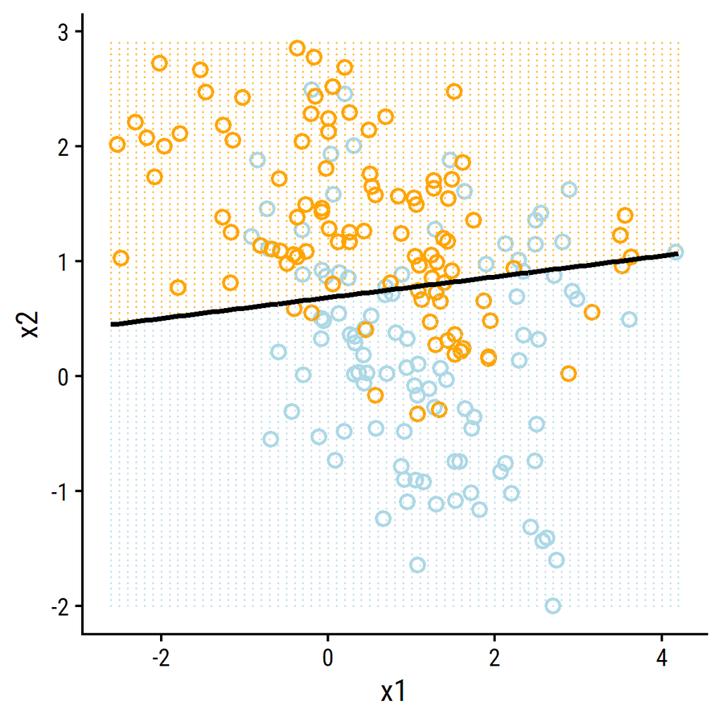

```r
beta <- as.numeric(coef(lm_fit_mixture$fit))
p_fig2.1 +
  geom_line(
    data = d_mixture_grid_pred %>%
      mutate(
        x2 = (0.5 - beta[1] - x1 * beta[2]) / beta[3]
      ),
    size = 1
  )
```

## 2.3.2 Nearest-Neighbor Methods

The $k$-nearest-neighbor fit for $\hat{Y}$ is given by:

$$\hat{Y}(x) = \frac{1}{k} \sum_{x \in N_k (x)} y_i \tag{2.8}$$

where $N_k(x)$ is the neighborhood of $x$ defined by the $k$ closest points to $x_i$ in the training set $\mathcal{T}$. For closeness, the simplest choice of metric is Euclidean distance.

Figure 2.2 employs a 15-nearest-neighbor fit:

```r
knn_k15_spec <-
  nearest_neighbor(
    neighbors = 15,
    # Note the dist_power argument, where a value of 2 corresponds to Euclidean
    #  distance (1 corresponds to Manhattan distance), and the weight_func
    #  argument which defines the kernel, where "rectangular" is unweighted knn
    dist_power = 2, weight_func = "rectangular") %>%
  set_engine("kknn") %>%
  set_mode("regression")
# The parsnip::translate() gives us the actual code used to fit the model
translate(knn_k15_spec)
```

```
## K-Nearest Neighbor Model Specification (regression)
##
## Main Arguments:
##   neighbors = 15
##   weight_func = rectangular
##   dist_power = 2
##
## Computational engine: kknn
##
## Model fit template:
## kknn::train.kknn(formula = missing_arg(), data = missing_arg(),
##     ks = min_rows(15, data, 5), kernel = "rectangular", distance = 2)
```

```r
knn_k15_fit_mixture <- knn_k15_spec %>%
  fit(y ~ x1 + x2, data = d_mixture)
knn_k15_fit_mixture
```

```
## parsnip model object
##
## Fit time:  0ms
##
## Call:
## kknn::train.kknn(formula = y ~ x1 + x2, data = data, ks = min_rows(15,     data, 5), distance = ~2, kernel = ~"rectangular")
##
## Type of response variable: continuous
## minimal mean absolute error: 0.304
## Minimal mean squared error: 0.1525333
## Best kernel: rectangular
## Best k: 15
```

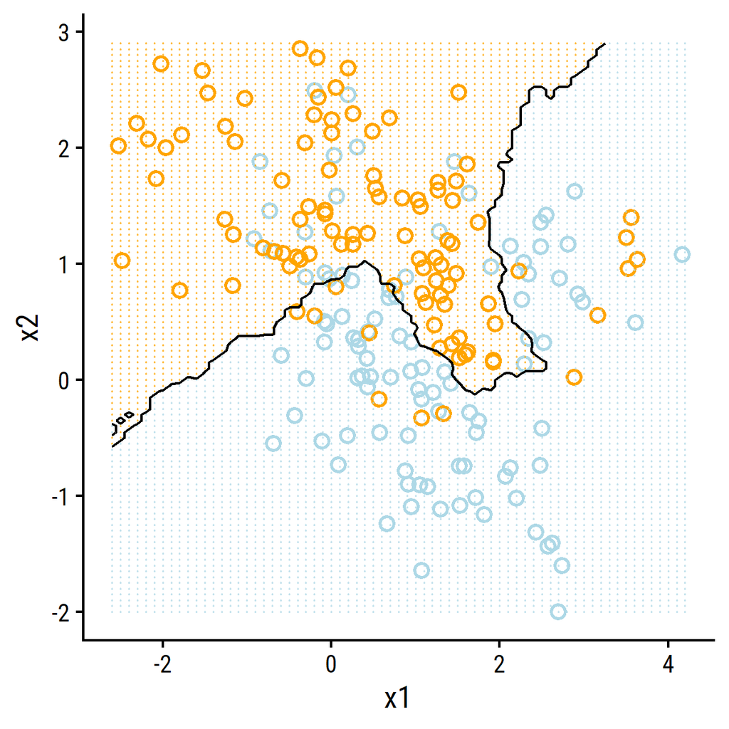

```r
d_mixture_grid_pred <-
  bind_cols(
    d_mixture_grid,
    predict(knn_k15_fit_mixture, d_mixture_grid)
  ) %>%
  mutate(y = ifelse(.pred > 0.5, 1, 0))

p_fig2.2 <- d_mixture %>%
  ggplot(aes(x = x1, y = x2)) +
  geom_point(aes(color = factor(y)), shape = 21, size = 2, stroke = 1) +
  scale_color_manual(values = c("lightblue", "orange")) +
  theme(legend.position = "none") +
  geom_point(
    data = d_mixture_grid_pred,
    aes(color = factor(y)), size = 0.05, alpha = 0.5
  ) +
  stat_contour(
    data = d_mixture_grid_pred, aes(z = .pred),
    color = "black", breaks = c(0.5)
  )
p_fig2.2
```

This doesn’t perfectly recreate the figure, but close enough.

Figure 2.3 is the same approach, except with $k = 1$:

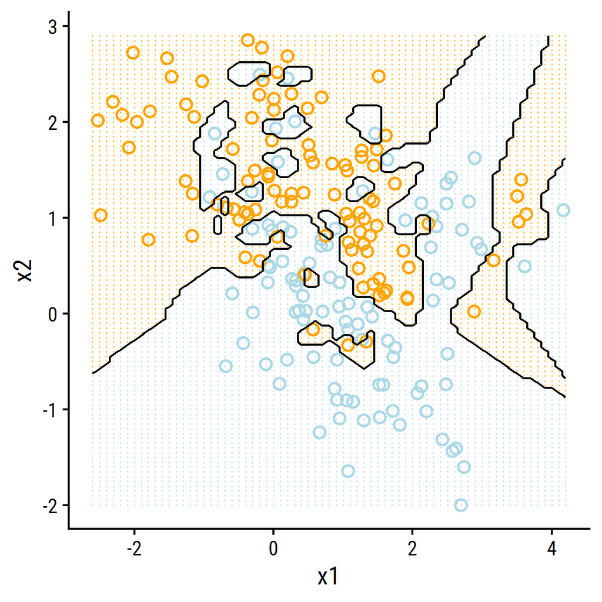

```r
knn_k1_spec <-
  nearest_neighbor(
    neighbors = 1,
    dist_power = 2, weight_func = "rectangular") %>%
  set_engine("kknn") %>%
  set_mode("regression")
knn_k1_fit_mixture <- knn_k1_spec %>%
  fit(y ~ x1 + x2, data = d_mixture)
d_mixture_grid_pred <-
  bind_cols(
    d_mixture_grid,
    predict(knn_k1_fit_mixture, d_mixture_grid)
  ) %>%
  mutate(y = ifelse(.pred > 0.5, 1, 0))

p_fig2.3 <- d_mixture %>%
  ggplot(aes(x = x1, y = x2)) +
  geom_point(aes(color = factor(y)), shape = 21, size = 2, stroke = 1) +
  scale_color_manual(values = c("lightblue", "orange")) +
  theme(legend.position = "none") +
  geom_point(
    data = d_mixture_grid_pred,
    aes(color = factor(y)), size = 0.05, alpha = 0.5
  ) +
  stat_contour(
    data = d_mixture_grid_pred, aes(z = .pred),
    color = "black", breaks = c(0.5)
  )
p_fig2.3
```

## 2.3.3 From Least Squares to Nearest Neighbors

In this section, we compare the two approaches in terms of their test error a testing set. The method of data simulation was

> The data in fact were simulated from a model somewhere between the two, but closer to Scenario 2. First we generated 10 means $m_k$ from a bivariate Gaussian distribution $N((1,0)^T, \bf{I})$ and labelled this class BLUE. Similarly, 10 more were drawn from $N(0,1)^T, \bf{I})$ and labelled class ORANGE.

The simulated means are actually provided in the `esl_mixture` data:

```r
d_sim_means1 <- as_tibble(esl_mixture$means, .name_repair = "unique") %>%
  rename(x1 = `...1`, x2 = `...2`) %>%
  mutate(
    # The first 10 means belong to the BLUE class, the second 10 to ORANGE
    y = c(rep(0, 10), rep(1, 10))
  )
d_sim_means1
```

| x1 | x2 | y |
| --- | --- | --- |
| -0.25343316 | 1.7414788 | 0 |
| 0.26669318 | 0.3712341 | 0 |
| 2.09646921 | 1.2333642 | 0 |
| -0.06127272 | -0.2086791 | 0 |
| 2.70354085 | 0.5968283 | 0 |
| 2.37721198 | -1.1864147 | 0 |
| 1.05690759 | -0.6838939 | 0 |
| 0.57888354 | -0.0683458 | 0 |
| 0.62425213 | 0.5987384 | 0 |
| 1.67335495 | -0.2893159 | 0 |

[output cut: 10 more lines]

But here is how I would simulate them myself with `MASS::mvrnorm`:

```r
set.seed(56)
d_sim_means2 <-
  MASS::mvrnorm(
    n = 10, mu = c(1, 0),
    Sigma = matrix(c(1, 0,
                     0, 1),
                   nrow = 2)
  ) %>%
  as_tibble(.name_repair = "unique") %>%
  mutate(y = 0) %>%
  bind_rows(
    MASS::mvrnorm(
      n = 10, mu = c(0, 1),
      # Here is a convenient way to generate an identify matrix
      Sigma = diag(2)
    ) %>%
      as_tibble(.name_repair = "unique") %>%
      mutate(y = 1)
  ) %>%
  rename(x1 = `...1`, x2 = `...2`)
d_sim_means2
```

| x1 | x2 | y |
| --- | --- | --- |
| 1.3106825505 | -0.240951560 | 0 |
| 0.5519376012 | -0.500406186 | 0 |
| 1.0419980916 | -0.395241357 | 0 |
| 1.9318072364 | -0.795269243 | 0 |
| 2.1601490285 | 0.539961086 | 0 |
| 1.4956744530 | 1.488931290 | 0 |
| 0.3728412551 | 0.467614398 | 0 |
| 0.7448708643 | 0.260633705 | 0 |
| 0.0964078374 | 0.683067519 | 0 |
| 0.2900677840 | -0.007191395 | 0 |

[output cut: 10 more lines]

Here is how my means compare to those from ESL:

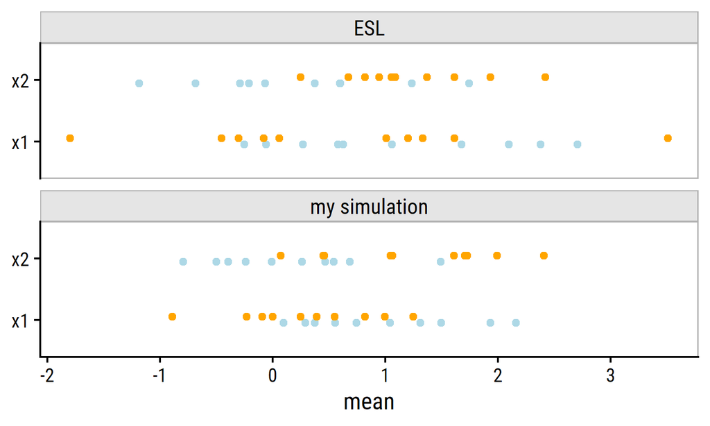

```r
d_sim_means1 %>%
  mutate(source = "ESL") %>%
  bind_rows(d_sim_means2 %>% mutate(source = "my simulation")) %>%
  pivot_longer(cols = c(x1, x2), names_to = "x", values_to = "mean") %>%
  ggplot(aes(y = x, x = mean, color = factor(y))) +
  geom_point(position = position_dodge(width = 0.2)) +
  facet_wrap(~source, ncol = 1) +
  scale_color_manual(values = c("lightblue", "orange")) +
  theme(legend.position = "none") +
  add_facet_borders() +
  labs(y = NULL)
```

Looks similar enough to me. The important thing to note is that, in the BLUE class, the values for $x_1$ (mean 1) are larger on average than $x_2$ (mean 0), and vice versa for the ORANGE class.